# EMP Benthic Data Analysis

Christina Burdi

11/30/2021

Benthic sampling includes both clam and amphipod data that we’re interested in.

Redoing benthic script with correct stations that were continuously monitored over the time series

Load packages

## Read in raw benthic count data

Benthic file does not exist locally so can get it from KMB: https://knb.ecoinformatics.org/knb/d1/mn/v2/object/urn:uuid:25b7befd-e931-4a50-9bf6-14715561f64a

```r
ben_raw = read.csv("data_raw/DWR Benthic raw count data 1975-2020 2021_10_01.csv")
```

## Clean and reprocess data

- Benthic survey used to sample on the L, R, or C of a site location historically, and eventually picked a side to monitor continuously, so need to remove the “Left, Right, Center” from the station names so can combine sites over the years.
- Want to make sure that we use all of the data from that site, despite which side it was sampled on
- Still want to keep A as a station designation
- Create a monthly time step to see which stations were sampled continuously over the years
- Take mean of lat/ long for each site since some sites moved slightly over the years based on the L, R, C

```r
ben <- ben_raw  %>%
  mutate(StationClean =  gsub("-[B-Z]","",StationCode)) %>% #Remove LRC from station code. Keep A station designation
  mutate(mon = lubridate::ym(paste0(Year, Month, sep = "-"))) %>% #create a month time step
  group_by(StationClean) %>%
  mutate(Latitude = mean(Latitude, na.rm = T), #take means of station locations
         Longitude = mean(Longitude, na.rm = T)) %>%
  ungroup()

sites_mon <- ben  %>%
  distinct(StationClean, Latitude, Longitude, mon)
```

## Graph which stations were sampled continuously over the time series

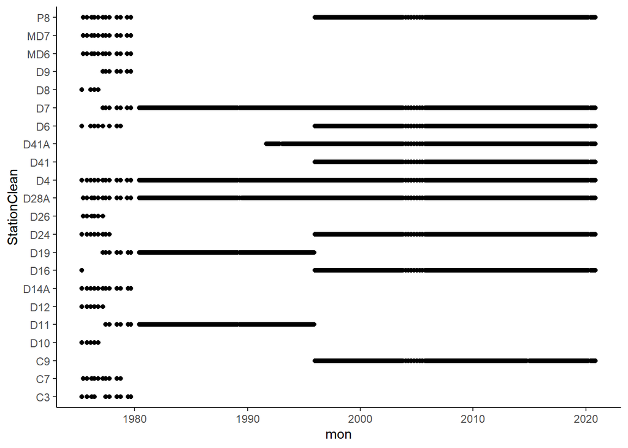

```r
#sites and number of months sampled to look at which were sampled continuously for analysis

sites <- ben %>%
  group_by(StationClean, Latitude, Longitude) %>%
  summarise(n_months = length(unique(mon)), .groups  =  "drop")

#graph of monthly sampling of each site over the time series

ggplot(sites_mon, aes(x = mon, y = StationClean), size = 3) +
  geom_point() +
  theme_classic()
```

only three stations were sampled consistently from 1977 to present.Stations D7 (Grizzly Bay), D4 (Chipps), D28A (franks Tract)

Additional stations picked up in the late 1990s

May want to eliminate clams from annual analysis based on small coverage with just those 3 sites, or combine sites close together. Need to explore.

## Map of sites colored with stations sampled continuously from 1980s, and 1990s. Scaled by months sampled

First specify which stations are from the 1980s and which are from the 1990s

```r
#stations sampled continuously since the 1980s

ben_1980 = c("D7",
               "D4",
               "D28A")

#stations sampled continuously since the 1990s

ben_1990 = c("P8",
             "D6",
             "D41",
             "D41A",
             "D24",
             "D16",
             "C9")
```

## Map of all stations

- Red = sites sampled continuously from the 1980s
- Blue = from the 1990s
- Black = sites not sampled continuously

```r
leaflet(sites) %>%
  addTiles() %>% #adds the default base map
  addCircleMarkers(data= sites, #all benthic sites
             lat = ~Latitude,
             lng = ~Longitude,
             label = ~StationClean,
             radius = ~n_months/ 50, #arbitrary scaling to show number of months each site was sampled
             color = "black",
             fillColor = "black",
             weight = 0.25,
             fillOpacity = 1) %>%
  addCircleMarkers(data = sites %>% filter(StationClean %in% ben_1980), #sites continuously from the 1980s
                   lat = ~Latitude,
                   lng = ~Longitude,
                   label = ~StationClean,
                   radius = ~n_months/ 50,
                   color = "black",
                   fillColor = "red",
                   weight = 0.25,
                   fillOpacity = 1) %>%
  addCircleMarkers(data = sites %>% filter(StationClean %in% ben_1990), #sites from the 1990s
                 lat = ~Latitude,
                 lng = ~Longitude,
                 label = ~StationClean,
                 radius = ~n_months/ 50,
                 color = "black",
                 fillColor = "blue",
                 weight = 0.25,
                 fillOpacity = 1)
```

[interactive chart not shown]

Write csv of stations sampled continuously for region analysis

```r
#stations for annual analysis (1980 to present)

write.csv(sites %>%
            filter(StationClean %in% ben_1980) %>%
            select(-n_months), "data/stations/stations_benthic_annual.csv")

#stations for monthly analysis (1997 to present)

write.csv(sites %>%
            filter(StationClean %in% c(ben_1980, ben_1990)) %>%
            select(-n_months), "data/stations/stations_benthic_monthly.csv")
```

## Calculate CPUE

- Do all critters first and then filter out later for what we want
- Benthic CPUE (organisms/ m2) = (Sum of organisms per visit/ # of grabs per visit)/ (0.052 grabs/ m2)
- Do CPUE with 1980 stations first for annual analysis. Need to explore other stations that we might need to combine to expand spatial coverage for annual data

```r
ben_LT = filter(ben, StationClean %in% c("D7", "D4", "D28A"))

LT_grabs_month  <- ben_LT %>%
  mutate(Date = paste(Month, Year)) %>%
  group_by(Date, StationCode, .drop = TRUE) %>%
  mutate(Grab_Count = max(Grab)) %>%
  distinct(Date, StationCode, Grab_Count) %>%
  group_by(Date) %>%
  summarise(Grab_Count = sum(Grab_Count))

LT_grabs_year <- LT_grabs_month %>%
  mutate(Date = lubridate::my(Date)) %>%
  mutate(Year = lubridate::year(Date)) %>%
  group_by(Year) %>%
  summarise(Grab_Count = sum(Grab_Count))

#verified grab totals by comparing to old EMP benthic CPUE file from Betsy Wells
```

## Calculate Annual CPUE for Clams

- Uses only the 1980s stations, and both clam genera

```r
LT_clams_year <- ben_LT %>%
  group_by(Genus, Year) %>%
  summarize(Orgs_Total = sum(Count, na.rm = TRUE), .groups = "drop") %>%
  left_join(LT_grabs_year) %>%
  mutate(CPUE_Total = (Orgs_Total/Grab_Count)/0.052) %>%
  filter(Genus %in% c("Potamocorbula", "Corbicula"))
#wide format for clams/ year

LT_clams_year_wide <- LT_clams_year %>%
  select(-Orgs_Total, -Grab_Count) %>%
  pivot_wider(names_from = Genus, values_from = CPUE_Total) %>%
  rename(Corbicula_cpue = Corbicula,
         Potamocorbula_cpue = Potamocorbula)

write.csv(LT_clams_year_wide, "data/annual_averages/clams_annual_noregions.csv")
```

## Calculate Annual CPUE for Amphipods

- 1980s stations, and combine all amphipod species for total amphipod CPUE

```r
LT_amph_year <- ben_LT %>%
  group_by(Order_level, Year) %>%
  summarize(Orgs_Total = sum(Count, na.rm = TRUE), .groups = "drop") %>%
  left_join(LT_grabs_year) %>%
  mutate(CPUE_Total = (Orgs_Total/Grab_Count)/0.052) %>%
  filter(Order_level == "Amphipoda")
LT_amph_year_wide <- LT_amph_year %>%
  select(-Orgs_Total, -Grab_Count) %>%
  pivot_wider(names_from = Order_level, values_from = CPUE_Total) %>%
  rename(Amphipoda_cpue = Amphipoda)

write.csv(LT_amph_year_wide, "data/annual_averages/amphipod_annual_noregions.csv")

#verified both amphipods and clam annual values by comparing it to Betsy's file
```

## Monthly CPUE for monthly/ regional analysis

Now need to calc monthly CPUE for the stations sampled in the 1990s for the monthly/ regional short term analysis Stations: D41, D41A, C9, D16, D24, D6, P8, D7, D4, D28A

CPUE with 10 ST stations, and limit to 1997 to present since D16 did not start till 1997

```r
ben_ST = filter(ben, StationClean %in% c("D41", "D41A", "C9", "D16", "D24", "D6", "P8", "D7", "D4", "D28A"), Year >1996)

ST_grabs_month  <- ben_ST %>%
  mutate(Date = paste(Month, Year)) %>%
  group_by(Date, StationCode, .drop = TRUE) %>%
  mutate(Grab_Count = max(Grab)) %>%
  distinct(Date, StationCode, Grab_Count) %>%
  group_by(Date) %>%
  summarise(Grab_Count = sum(Grab_Count))
```

## Calc monthly CPUE for just clams at the 1990 stations

```r
ST_clams_mon <- ben_ST %>%
  mutate(Date = paste(Month, Year)) %>%
  group_by(Genus,Date) %>%
  summarize(Orgs_Total = sum(Count, na.rm = TRUE), .groups = "drop") %>%
  left_join(ST_grabs_month) %>%
  mutate(CPUE_Total = (Orgs_Total/Grab_Count)/0.052) %>%
  filter(Genus %in% c("Potamocorbula", "Corbicula"))
#wide format for clams/ month

ST_clams_mon_wide <- ST_clams_mon %>%
  select(-Orgs_Total, -Grab_Count) %>%
  pivot_wider(names_from = Genus, values_from = CPUE_Total) %>%
  rename(Corbicula_cpue = Corbicula,
         Potamocorbula_cpue = Potamocorbula)

write.csv(ST_clams_mon_wide, "data/monthly_averages/clams_ST_monthly.csv")
```

## Amphipod monthly CPUE

```r
ST_amph_mon <- ben_ST %>%
  mutate(Date = paste(Month, Year)) %>%
  group_by(Order_level,Date) %>%
  summarize(Orgs_Total = sum(Count, na.rm = TRUE), .groups = "drop") %>%
  left_join(ST_grabs_month) %>%
  mutate(CPUE_Total = (Orgs_Total/Grab_Count)/0.052) %>%
  filter(Order_level == "Amphipoda")
#wide format for amph/ month

ST_amph_mon_wide <- ST_amph_mon %>%
  select(-Orgs_Total, -Grab_Count) %>%
  pivot_wider(names_from = Order_level, values_from = CPUE_Total) %>%
  rename(Amphipod_cpue = Amphipoda)

write.csv(ST_amph_mon_wide, "data/monthly_averages/amphipod_ST_monthly.csv")

#verified monthly averages by randomly comparing to CPUE of old EMP benthic file
```

## Regional Analyses

- Assign annual and monthly stations to regions
- Plot to make sure all stations fall into a region
- Add region assignments to benthic file for monthly and annual analysis

```r
ben_LT_Reg= ben_LT %>%
  region_assigner(analysis="annual")
```

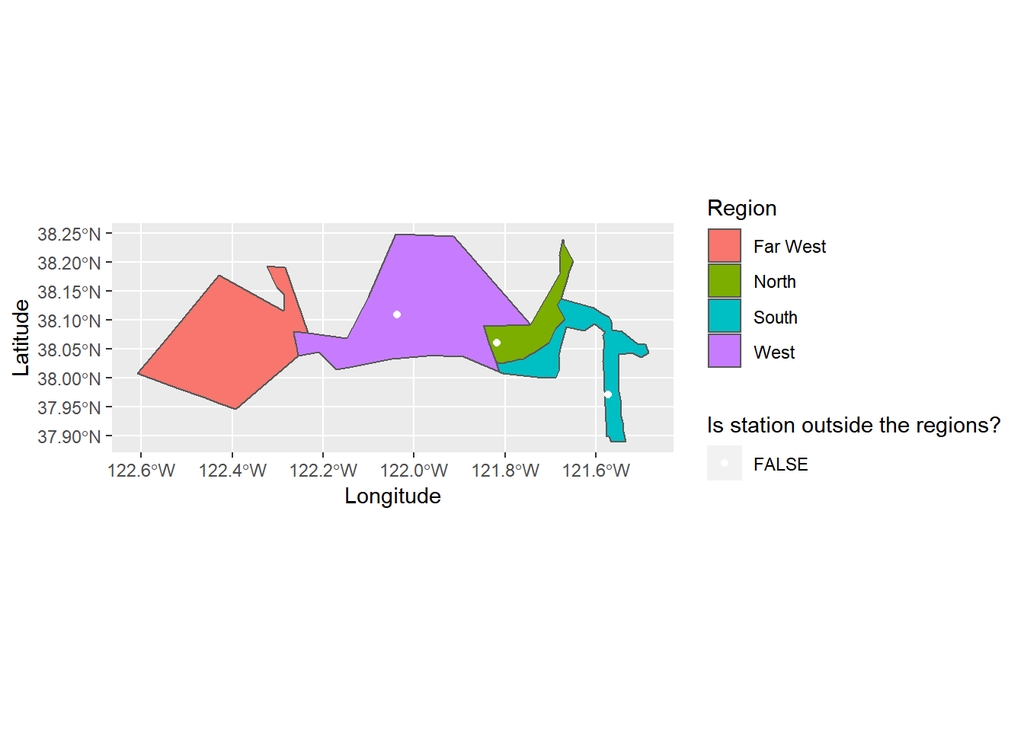

```r
ben_st_reg= ben_ST %>%
  region_assigner(analysis="monthly") #Stations C9 and P8 are dropped due to being outside the south region
```

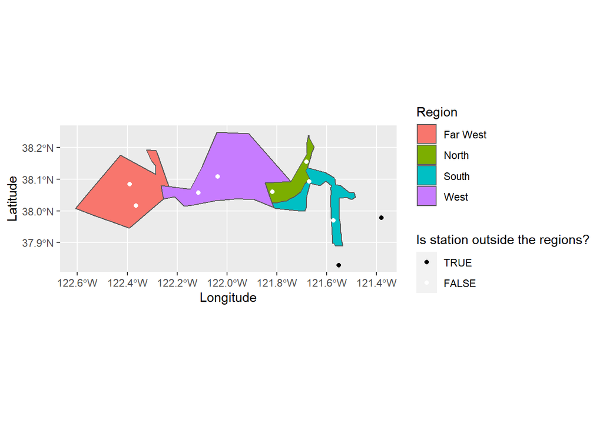

## Calculating CPUE with regions assigned

- Recalculate CPUE for
- 1. Clam and Amphipod Annual w/o Regions (already done earlier)
- 2. Clam and Amphipod Annual with Regions and
- 3. Clam and Amphipod monthly with Regions

```r
#clam annual CPUE with region

Reg_clams_year <- ben_LT_Reg %>%
  group_by(Genus, Year, Region) %>%
  summarize(Orgs_Total = sum(Count, na.rm = TRUE), .groups = "drop") %>%
  left_join(LT_grabs_year) %>%
  mutate(CPUE_Total = (Orgs_Total/Grab_Count)/0.052) %>%
  filter(Genus %in% c("Potamocorbula", "Corbicula"))
reg_clams_year_wide <- Reg_clams_year %>%
  select(-Orgs_Total, -Grab_Count) %>%
  pivot_wider(names_from = Genus, values_from = CPUE_Total) %>%
  rename(Corbicula_cpue = Corbicula,
         Potamocorbula_cpue = Potamocorbula)

write.csv(reg_clams_year_wide, "data/annual_averages/clams_annual_regions.csv")

#amphipod annual with regions

reg_amph_year <- ben_LT_Reg %>%
  group_by(Order_level, Year, Region) %>%
  summarize(Orgs_Total = sum(Count, na.rm = TRUE), .groups = "drop") %>%
  left_join(LT_grabs_year) %>%
  mutate(CPUE_Total = (Orgs_Total/Grab_Count)/0.052) %>%
  filter(Order_level == "Amphipoda")
reg_amph_year_wide <- reg_amph_year %>%
  select(-Orgs_Total, -Grab_Count) %>%
  pivot_wider(names_from = Order_level, values_from = CPUE_Total) %>%
  rename(Amphipoda_cpue = Amphipoda)

write.csv(reg_amph_year_wide, "data/annual_averages/amphipod_annual_regions.csv")


#clam monthly with region

reg_clams_mon <- ben_st_reg %>%
  mutate(Date = paste(Month, Year)) %>%
  group_by(Genus,Date, Region) %>%
  summarize(Orgs_Total = sum(Count, na.rm = TRUE), .groups = "drop") %>%
  left_join(ST_grabs_month) %>%
  mutate(CPUE_Total = (Orgs_Total/Grab_Count)/0.052) %>%
  filter(Genus %in% c("Potamocorbula", "Corbicula"))
reg_clams_mon_wide <- reg_clams_mon %>%
  select(-Orgs_Total, -Grab_Count) %>%
  pivot_wider(names_from = Genus, values_from = CPUE_Total) %>%
  rename(Corbicula_cpue = Corbicula,
         Potamocorbula_cpue = Potamocorbula)

write.csv(ST_clams_mon_wide, "data/monthly_averages/clams_monthly_regions.csv")


#amphipod monthly with regions

reg_amph_mon <- ben_st_reg %>%
  mutate(Date = paste(Month, Year)) %>%
  group_by(Order_level,Date, Region) %>%
  summarize(Orgs_Total = sum(Count, na.rm = TRUE), .groups = "drop") %>%
  left_join(ST_grabs_month) %>%
  mutate(CPUE_Total = (Orgs_Total/Grab_Count)/0.052) %>%
  filter(Order_level == "Amphipoda")
reg_amph_mon_wide <- reg_amph_mon %>%
  select(-Orgs_Total, -Grab_Count) %>%
  pivot_wider(names_from = Order_level, values_from = CPUE_Total) %>%
  rename(Amphipod_cpue = Amphipoda)

write.csv(reg_amph_mon_wide, "data/monthly_averages/amphipod_monthly_regions.csv")
```